# WW_project_v2

2026-11-01

## Introduction

Wastewater based epidemiology(WBE) has reemerged as a public health surveillance tool for tracking infectious diseases at the community level through the analysis of sewage. Increased interest occurred during the COVID-19 (SARS-COV-2) pandemic, with the Centers for Disease Control and Prevention (CDC) establishing the National Wastewater Surveillance System (NWSS) partnering with major projects like WastewaterSCAN.

This report utilizes the CDC Wastewater Viral Activity Level (WVAL), which records weekly surveillance measurements across U.S wastewater treatment faculties for respiratory pathogens SARS-COV-2, Influenza A and Respiratory syncytial virus (RSV).

## Objectives

1. Load the wastewater surveillance dataset from the online repository (Limited to 50,000 rows of data, since the dataset has over 500K)
2. Construct summary tables evaluating categorical viral activity
3. Visualize the viral activity levels over time to identify seasonal trends

## References

https://www.cdc.gov/wastewater/about-data/index.html

https://pmc-ncbi-nlm-nih-gov.proxy.library.emory.edu/articles/PMC11312382/

https://www.nature.com/articles/s41370-024-00683-w#citeas

## Load data

Data loaded from data.cdc.gov via url.

### Variables of interest:

**pathogen_target**: Pathogen for which wastewater viral activity levels calculated

**week_end**: Last date in one week time period for CDC/MMWR reporting week

**Site_WVAL_Category**: Category for the calculated site WVAL for the CDC/MMWR reporting week. Categories are ordinal based on pathogen specific cut-offs of WVAL values: very low, low, moderate, high, very high; limited/no data: category when there is insufficient data to calculate a WVAL.

**Site_WVAL**: The calculated site wastewater viral activity level (WVAL) for the CDC/MMWR reporting week

## Analysis Table

The table below summarizes the distribution of weekly site level viral activity categories grouped by pathogens (pathogen_target) across 2026.

| **Characteristic** | **Overall** N = 50,000<sup>1</sup> | **Influenza A virus** N = 16,332<sup>1</sup> | **RSV** N = 15,453<sup>1</sup> | **SARS-CoV-2** N = 18,215<sup>1</sup> |
| --- | --- | --- | --- | --- |
| Activity Category |  |  |  |  |
| High | 2,190 (4.4%) | 195 (1.2%) | 174 (1.1%) | 1,821 (10.0%) |
| Low | 5,693 (11%) | 1,309 (8.0%) | 846 (5.5%) | 3,538 (19%) |
| Moderate | 3,716 (7.4%) | 675 (4.1%) | 386 (2.5%) | 2,655 (15%) |
| Very High | 2,480 (5.0%) | 195 (1.2%) | 243 (1.6%) | 2,042 (11%) |
| Very Low | 35,921 (72%) | 13,958 (85%) | 13,804 (89%) | 8,159 (45%) |
| Site Metric (WVAL) | 97.1 (12,831.2) [Med: 1.0] | 23.5 (2,648.9) [Med: 1.0] | 280.5 (22,917.4) [Med: 1.0] | 7.4 (222.6) [Med: 3.1] |

<sup>1</sup> n (%); Mean (SD) [Med: Median]

## Visualizing Analysis

To observing pathogen trajectories over 2026, I aggregated the mean weekly site viral activity metric (site_WVAL).

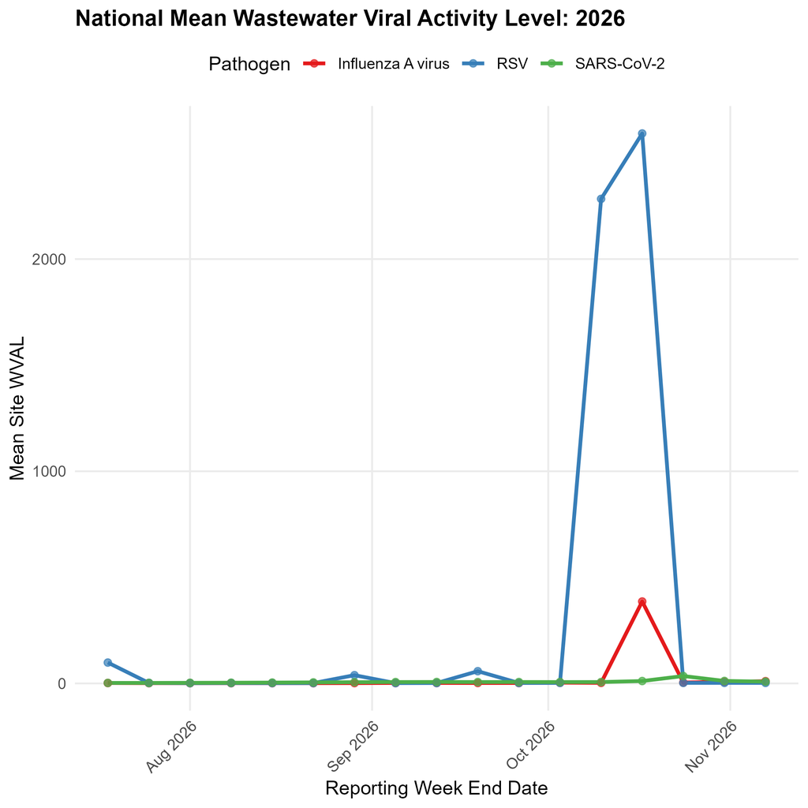